# 3I026 - Intelligence artificielle & Data science

# Projet

[Université Pierre et Marie Curie](http://www.upmc.fr/)

### Notebook fait par Stéphane Betolaud et Walid Laouer

## Données

Nous avons travailler sur les données du projet Kaggle *European Soccer Database* accessible à l'adresse https://www.kaggle.com/hugomathien/soccer.

Les données en version SQLite sur la page http://www-connex.lip6.fr/~schwander/3I026/soccer.zip ou en version CSV http://www-connex.lip6.fr/~denoyer/wordpress/wp-content/uploads/2018/01/soccer.tar.gz.

Nous avons donc utilisé ces données pour effectuer une analyse et pour faire un modèle predictif.

## Partie 1 - Description du problème

- comprendre les attributs contenus dans le jeu de données et ainsi pouvoir voir quels sont les attribus que nous allons utiliser dans la suite pour pouvoir analyser nos données.
- Ensuite nous allons procéder à une analyse prospective des données afin de mieux comprendre la topologie des données.
- Puis, nous allons effectuer un modèle prédictif qui va pouvoir prédire selon nos données si nous pouvons avoir le vainqueur d'un match.

## Bibliothèques nécessaires

Afin de pouvoir faire notre analyse, nous allons devoir importer différentes bibliothèques que python nous propose. Nous allons donc devoir importer :

- [NumPy](http://www.numpy.org/) : permet de manipuler facilement des matrices ou des tableaux à plusieurs dimensions, ainsi que des outils mathématiques.
- [Panda](http://pandas.pydata.org/) : permet l'analyse de données et permet de manipuler des données facilement.
- [DateTime](https://docs.python.org/2/library/datetime.html) : permet de manipuler des dates et des durées sous forme d'objet
- [MatplotLib](https://matplotlib.org/) : permet de visualiser des données sous forme de graphiques. on utilisera ici pyplot faisant partie de la bibliothèque MatplotLib pour pouvoir tracer nos graphiques.
- [sqlite3](https://www.sqlite.org/index.html) : permet de recuperer nos données grace a des requêtes sql.
- [Math](https://docs.python.org/2/library/math.html) : permet d'obtenir tous les objets mathématiques que nous voulons utiliser.

## Partie 2 - Modèle

```python
import numpy as np
import matplotlib.pyplot as plt
import pandas as pd
import sqlite3
import math
```

Les deux bloc suivants servent à récuperer les tables avec lesquelles nous allons travailler. Nous avons stocké dans des variables toutes les tables qui sont disponibles sur le site de [kaggle](https://www.kaggle.com/hugomathien/soccer) afin de pouvoir travailler dessus.

```python
path="/"
database = "database.sqlite"
conn = sqlite3.connect(database)
```

```python
country = pd.read_sql("select * from country",conn)
league = pd.read_sql("select * from league",conn)
match = pd.read_sql("select * from match",conn)
player = pd.read_sql("select * from player",conn)
player_attributes = pd.read_sql("select * from player_attributes",conn)
team = pd.read_sql("select * from team",conn)
team_attributes = pd.read_sql("select * from team_attributes",conn)
```

Afin de faire un modèle predictif, nous devons implémenter un LabeledSet qui sert à prendre des valeurs avec des labels qui nous serviront pour faire tourner nos algorithmes de prédiction.

```python
class LabeledSet:

    def __init__(self,input_dimension):
        self.input_dimension=input_dimension
        self.nb_examples=0

    def addExample(self,vector,label):
        if (self.nb_examples==0):
            self.x=np.array([vector])
            self.y=np.array([label])
        else:
            self.x=np.vstack((self.x,vector))
            self.y=np.vstack((self.y,label))

        self.nb_examples=self.nb_examples+1

    def addExample2(self,set):
        for i in range(set.size()):
            self.addExample(set.getX(i),set.getY(i))

    #Renvoie la dimension de l'espace d'entrée
    def getInputDimension(self):
        return self.input_dimension


    #Renvoie le nombre d'exemples dans le set
    def size(self):
        return self.nb_examples

    #Renvoie la valeur de x_i
    def getX(self,i):
        return self.x[i]


    #Renvouie la valeur de y_i
    def getY(self,i):
        return(self.y[i])
```

### Implémentation du KNN

```python
from math import *
import scipy
import scipy.spatial
pre=9
def d_euclidienne(v1,v2):
    global pre
    scipy.spatial.distance.euclidean(v1,v2)
class Classifier:
    def __init__(self,input_dimension):
        raise NotImplementedError("Please Implement this method")


    #Permet de calculer la prediction sur x => renvoie un score
    def predict(self,x):
        raise NotImplementedError("Please Implement this method")


    #Permet d'entrainer le modele sur un ensemble de données
    def train(self,labeledSet):
        raise NotImplementedError("Please Implement this method")

    #Permet de calculer la qualité du système
    def accuracy(self,set):
        total = set.size()
        gp = 0.
        for i in range(total):

            #bonne reconnaissance faite par le classifier
            score = self.predict(set.getX(i))
            if score == set.getY(i) :
                gp += 1
        return gp/total
```

Nous avons ici implementé un premier KNN qui nous servira pour une partie des données que nous allons utiliser.

```python
class KNN(Classifier):
    def __init__(self, input_dimension,k):
        self.input_dimension= input_dimension
        self.w=LabeledSet(input_dimension)
        self.k=k

    def getW(self):
        return self.w

    def train(self,x):

        self.w.addExample2(x)

    def predict(self,x):
        vd = [(0, d_euclidienne(self.w.getX(0), x))]

        for i in range(1, self.w.size()):
            dist = d_euclidienne(self.w.getX(i), x)
            j = 0
            if vd[j][1] is None :
                continue
            while j < len(vd) and dist > vd[j][1]:
                j+=1

            vd.insert(j, (i, dist))


        c = vd[0:self.k]
        s = sum([self.w.getY(x) for x,y in c])
        if s > 0:
            return 1
        else:
            return 0
```

Nous avons ici implémenté un second KNN, plus traditionnel qui nous servira aussi mais pour des données différentes.

```python
class KNN2():

    def __init__(self,k):
        self.k=k
        self.dataset=None
        self.labelset=None

    def distance(self,coord):
        l=len(coord)
        dist=[]
        for i in range(self.dataset.shape[0]):
            d=0
            for j in range(l):
                x=coord[j]-self.dataset.iloc[i][j]
                x=pow(x,2)
                d=d+x
            dist.append(d)

        dist=np.array(dist)
        distInd=dist.argsort()
        return distInd

    def predict(self,x):
        distInd=self.distance(x)
        if(self.k==1):
            return self.labelset.iloc[distInd[0]][0]

        else:
            cpt=0
            for i in range(0,self.k):
                ind=distInd[i]
                if(self.labelset.iloc[ind][0]==1):
                    cpt+=1
                else:
                    cpt-=1
            if(cpt>=0):
                return 1
            else:
                return -1

    def train(self, dataset,labelset):
        self.dataset=dataset
        self.labelset=labelset

    def accuracy(self, dataset,labelset):
        score=0
        good=0
        for i in range(dataset.shape[0]):
            score=self.predict(dataset.iloc[i][:])
            if(score==labelset.iloc[i][0]):
                good=good+1

        return (good*100.0/dataset.shape[0])
```

### Implémentation du Perceptron

```python
class Perceptron2():
    def __init__(self, learning_rate):

        self.learning_rate=learning_rate
        self.w = None


    def train(self,trainingset,labelset):
        self.input_dimension=trainingset.shape[1]
        self.w=np.random.rand(self.input_dimension) * 2 -1

        for j in range(trainingset.shape[0]) :
            teams=trainingset.ix[j]
            if(labelset.iloc[j][0]*self.predict(teams)<0):


                self.w=self.w+self.learning_rate*labelset.iloc[j][0]*teams
                                                    #expected       #x

    def predict(self, x):
        z= np.dot(self.w, x) #home team

        if z > 0: # ou superieur a 0.5 on verra
            return +1 # donc home team a win
        else:
            return -1 # donc away team a win

    def accuracy(self, dataset, labelset):
        nb_ok = 0
        for i in range(dataset.shape[0]):
            output = self.predict(dataset.iloc[i][:])
            if output*labelset.iloc[i][0]>0:
                nb_ok+=1
        acc = nb_ok / (dataset.shape[0]*1.0)
        return acc


#learning_rate  -> fluctuation
#2ieme attribut de sert a rien
```

## Partie 3 - Code

#### I. Compréhension des données

Nous allons regarder les attributs qui peuvent etre interressants pour la prediction de matchs. Nous avons deja lu toutes les bases que nous avons stocker dans des variables.

```python
player_attributes.head()
```

|  | id | player_fifa_api_id | player_api_id | date | overall_rating | potential | preferred_foot | attacking_work_rate | defensive_work_rate | crossing | ... | vision | penalties | marking | standing_tackle | sliding_tackle | gk_diving | gk_handling | gk_kicking | gk_positioning | gk_reflexes |
| --- | --- | --- | --- | --- | --- | --- | --- | --- | --- | --- | --- | --- | --- | --- | --- | --- | --- | --- | --- | --- | --- |
| 0 | 1 | 218353 | 505942 | 2016-02-18 00:00:00 | 67.0 | 71.0 | right | medium | medium | 49.0 | ... | 54.0 | 48.0 | 65.0 | 69.0 | 69.0 | 6.0 | 11.0 | 10.0 | 8.0 | 8.0 |
| 1 | 2 | 218353 | 505942 | 2015-11-19 00:00:00 | 67.0 | 71.0 | right | medium | medium | 49.0 | ... | 54.0 | 48.0 | 65.0 | 69.0 | 69.0 | 6.0 | 11.0 | 10.0 | 8.0 | 8.0 |
| 2 | 3 | 218353 | 505942 | 2015-09-21 00:00:00 | 62.0 | 66.0 | right | medium | medium | 49.0 | ... | 54.0 | 48.0 | 65.0 | 66.0 | 69.0 | 6.0 | 11.0 | 10.0 | 8.0 | 8.0 |
| 3 | 4 | 218353 | 505942 | 2015-03-20 00:00:00 | 61.0 | 65.0 | right | medium | medium | 48.0 | ... | 53.0 | 47.0 | 62.0 | 63.0 | 66.0 | 5.0 | 10.0 | 9.0 | 7.0 | 7.0 |
| 4 | 5 | 218353 | 505942 | 2007-02-22 00:00:00 | 61.0 | 65.0 | right | medium | medium | 48.0 | ... | 53.0 | 47.0 | 62.0 | 63.0 | 66.0 | 5.0 | 10.0 | 9.0 | 7.0 | 7.0 |

5 rows × 42 columns

On voit que au niveau d'une seule table il y a beaucoup de données. Nous allons donc devoir utiliser ces tables pour isoler des attributs qui nous semblent interessants pour la prediction. Nous allons commencer par regarder le nombre total de matchs, le nombre de victoires le nombre de defaites et le nombre de matchs nuls.

```python
score_domicile = match["home_team_goal"]
score_exterieur = match["away_team_goal"]
victoires = 0
total_matchs = np.size(score_domicile)
nuls = 0
print(total_matchs)
for i in range(0,np.size(score_domicile)):
    if score_exterieur[i] == score_domicile[i]:
        nuls +=1
    else :
        victoires +=1
print("victoires : %s" %(victoires))
print("nuls : %s" %(nuls))
```

```
25979
victoires : 19383
nuls : 6596
```

Nous pouvons voir que le nombre total de matchs est de 25979 et que le nombre de victoires sont de 19383 et le nombre de matchs nuls sont de 6596. Nous pouvons aussi regarder quelles sont les equipes qui ont le plus de victoires et faire un classement de toutes les equipes en fonction de leur nombre de victoires.

```python
dico = {}
dico2 ={}
id_dom = match["home_team_api_id"]
id_ext = match["away_team_api_id"]
api_id_team = team["team_api_id"]
print(np.size(api_id_team))

for i in range(0,np.size(api_id_team)):
    dico[api_id_team[i]] = 0
    dico2[api_id_team[i]]=0

for i in range(0,np.size(score_domicile)):
    if score_domicile[i]>score_exterieur[i]:
        dico[id_dom[i]] +=1
        #print(dico[id_dom[i]] )
    else :
        dico[id_ext[i]] +=1
        #print(dico[id_ext[i]])
dico = sorted(dico.items(),key=lambda x : x[1] , reverse=True)
print(dico)
```

```
299
[(8634, 265), (8633, 253), (9925, 245), (10260, 233), (9885, 225), (9823, 223), (9847, 219), (8456, 218), (9931, 218), (8593, 216), (8455, 212), (9825, 209), (9773, 209), (8640, 207), (9772, 206), (9906, 202), (8639, 200), (8686, 200), (8564, 199), (9748, 193), (9875, 192), (8592, 191), (8636, 190),…
```

Avec le dictionnaire que nous avons créé, nous pouvons donc visualiser quelles sont les equipes qui ont e plus grand nombre de victoires.

Nous avons aussi récuperer le classement de la ligue 1 pour une seule saison pour voir si nous pouvions recuperer tous les classements de toutes les saisons de chaque ligue.

```python
#regarder le nombre de matchs en tout en ligue 1

ligue1 = pd.read_sql("select * from league",conn)
ligue1
matchligue1 = pd.read_sql("select * from match where country_id='4769'",conn)
matchligue1
match_psg_domicile = pd.read_sql("select distinct * from match, team where country_id='4769' and home_team_api_id = '9847' and away_team_api_id !='9847' and season = '2008/2009' order by stage ", conn)
match_psg_domicile




match_psg_domicile
stage=[]
for i in match_psg_domicile["stage"] :
    if(i not in stage):
        stage.append(i)

equipes_exterieur=[]
for i in match_psg_domicile["away_team_api_id"]:
    if(i not in equipes_exterieur):
        equipes_exterieur.append(i)
print(equipes_exterieur)
```

```
[9827, 9830, 9855, 8689, 9941, 8639, 9748, 8682, 9873, 9874, 7819, 9853, 8481, 8592, 9831, 9746, 9851, 8583, 9829]
```

Puis nous avons implémenté un algorithme permettant d'obtenir le classement général en fonction de la ligue et de la saison (pour l'application de l'algo il faut décommenter la dernière partie du code en rouge)

```python
liste_league = []
league = pd.read_sql("select id from league group by id",conn)
for i in league["id"] :
        liste_league.append(i)



liste_season = []
season = pd.read_sql("select season from match group by season",conn)
for i in season["season"] :
        liste_season.append(i)


def classement_gen(league,annee):

    matchligue1 = pd.read_sql("select home_team_api_id,away_team_api_id,home_team_goal,away_team_goal, stage from match where country_id='%s' and season = '%s' order by stage,date"%(league,annee),conn)
    home = matchligue1["home_team_api_id"]
    d={}
    for i in home :
        d[i]=0

    domicile = matchligue1["home_team_goal"]
    exterieur = matchligue1["away_team_goal"]
    nom_domicile = matchligue1["home_team_api_id"]
    nom_exterieur = matchligue1["away_team_api_id"]

    for i in range(domicile.size) :
        if domicile[i] < exterieur[i] :
            d[nom_exterieur[i]]+=3
        if domicile[i] >exterieur[i] :
            d[nom_domicile[i]]+=3
        if domicile[i] == exterieur[i] :
            d[nom_exterieur[i]]+=1
            d[nom_domicile[i]]+=1

    d= sorted(d.items(),key=lambda x : x[1] , reverse=True)
    return d




#for i in liste_league :
#    for j in liste_season :
#        print("-----------------------------------------")
#        print(i,j)
#        print("******************************************")
#        print(classement_gen(i,j))
#        print('+++++++++++++++++++++++++++++++++++++++++++')
```

Puis nous avons implémenté des algorithmes qui permet d'obtenir l'evolution du classement de chaque équipe en fonction des saisons.

```python
matchligue1 = pd.read_sql("select season home_team_api_id,away_team_api_id,home_team_goal,away_team_goal, stage from match where country_id='4769' and season = '2008/2009' order by stage,date" ,conn)

saison = classement_gen(4769,'2008/2009')
#print(saison)
L=[]
for i in saison :
    L.append(i[0])
#print(L)
dico = {}
for i in range(0,len(L)):
    dico[L[i]] = i+1
#print(dico)

def getClassement(liste_tuple) :
    L=[]
    for i in liste_tuple :
        L.append(i[0])
    dico = {}
    for i in range(0,len(L)):
        dico[L[i]]= i+1
    dico = sorted(dico.items(),key=lambda x : x[1] , reverse=False)
    return dico
print(getClassement(saison))


def getSaison(i):
    return liste_league[i]
getSaison(2)
```

```
[(9827, 1), (8592, 2), (9748, 3), (8639, 4), (9847, 5), (9941, 6), (9851, 7), (8583, 8), (9831, 9), (9829, 10), (8689, 11), (9873, 12), (9855, 13), (8481, 14), (9874, 15), (8682, 16), (9853, 17), (7819, 18), (9830, 19), (9746, 20)]
```

```
4769
```

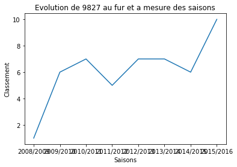

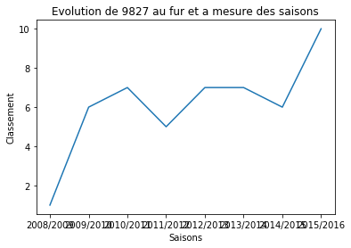

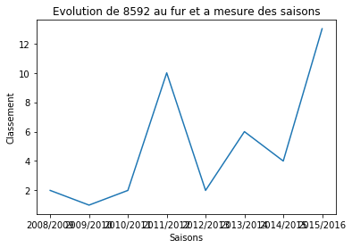

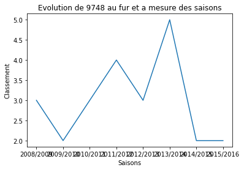

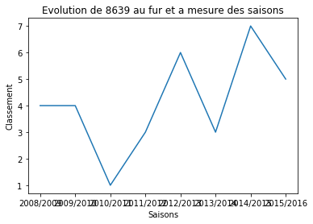

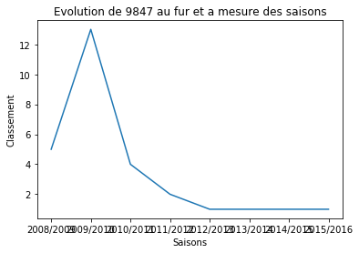

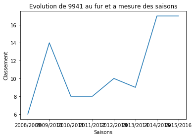

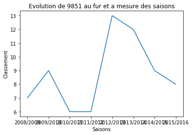

[output not shown]

```python
def getEquipesligue1():
    saison = classement_gen(4769,'2008/2009')
    classement = getClassement(saison)
    liste_equipes = []
    for i in classement :
        liste_equipes.append(i[0])
    return liste_equipes


def graph_equipe_ligue1(equipe):
    saisons = liste_season
    liste_classement_equipe = []
    for i in saisons :
        classement = classement_gen(4769,i)
        classement2 = getClassement(classement)
        for j in classement2 :
            if j[0] == equipe :
                liste_classement_equipe.append(j[1])
    #on a dans saisons les differentes saisons
    #on a dans liste_classement_equipe le classement de l'equipe au fur et a mesure des saisons
    plt.title("Evolution de %s au fur et a mesure des saisons" %(equipe))
    plt.xlabel("Saisons")
    plt.ylabel("Classement")
    plt.plot(saisons,liste_classement_equipe)
    plt.show()


equipe = 9827
saisons = liste_season
liste_classement_equipe = []
for i in saisons :
    classement = classement_gen(4769,i)
    for j in classement :
        if j[0] == equipe :
            liste_classement_equipe.append(j[1])
graph_equipe_ligue1(equipe)

for i in getEquipesligue1():
    graph_equipe_ligue1(i)
```

Nous avons aussi récuperer le pourcentage de victoires de chaque équipe.

```python
pourcentage = []
pourcentage = getPourcentage(liste_classement[0])
pourcentage = pourcentage[0]

for i in range(len(pourcentage)):
    if i>9:
        pourcentage[i]=-pourcentage[i]


ligue1 = liste_league[2]
liste_classement = []
for i in liste_season :
    liste_classement.append(classement_gen(ligue1 , i))
print(liste_classement)

#retoune la liste des pourcentages de chaque equipe triés
def getPourcentage(liste_tuple ):
    points = 0
    for i in liste_tuple :
        points += i[1]
    L=[]
    L2 =[]
    for i in liste_tuple :
        L.append(i[1]/points)
        L2.append(i[0])
    return (L,L2)

def getPourcentage2(liste_tuple ):
    points = 0
    for i in liste_tuple :
        points += i[1]
    L=[]
    L2 =[]
    for i in liste_tuple :
        L.append(i[1]/points)
        L2.append(i[0])
    return L

def getPourcentagefinal(liste_pourcentage):
    liste_finale =[]
    for i in range(0,len(pourcentage)):
        if i<=10:
            liste_finale.append(pourcentage[i])
        else:
            liste_finale.append(-pourcentage[i])
    return liste_finale

getPourcentagefinal(pourcentage)





#on recupere les 4 premieres saisons et les 4 dernieres separement pour le knn
liste_4_premieres_annees = []
liste_4_dernieres_annees = []
for i in range(0,len(liste_classement)//2):
    liste_4_premieres_annees.append(liste_classement[i])


for i in range(len(liste_classement)//2,len(liste_classement)):
    liste_4_dernieres_annees.append(liste_classement[i])


liste_pourcentage2 =[]
liste_pourcentage3 =[]
for i in liste_4_premieres_annees :
    pourcentage2 = getPourcentage2(i)
    liste_pourcentage2.append(pourcentage2)
for i in liste_pourcentage2 :
    pourcentage3 = getPourcentagefinal(i)
    liste_pourcentage3.append(pourcentage3)


#on obtient une liste de listes de pourcentages de toutes les saisons dans liste_pourcentage3
print(liste_4_dernieres_annees)
```

```
[[(9827, 80), (8592, 77), (9748, 71), (8639, 64), (9847, 64), (9941, 64), (9851, 61), (8583, 55), (9831, 50), (9829, 45), (8689, 45), (9873, 44), (9855, 44), (8481, 42), (9874, 42), (8682, 40), (9853, 40), (7819, 37), (9830, 37), (9746, 26)], [(8592, 78), (9748, 72), (8583, 71), (8639, 70), (10249, …
[[(9847, 83), (8592, 71), (9748, 67), (9831, 64), (9853, 63), (8639, 62), (9827, 55), (8689, 53), (10249, 52), (9941, 51), (9873, 48), (7794, 47), (9851, 46), (9837, 43), (8576, 42), (9874, 41), (4087, 40), (8481, 38), (10242, 37), (8521, 29)], [(9847, 89), (9829, 80), (8639, 71), (9853, 69), (9748,…
```

Dans ce notebook nous allons uniquement nous intéresser à la prediction de matchs. Une partie de notre exploration de donnée va donner suite à un autre notebook qui nous permettra de prédire si une équipe est en début ou en fin de classement.

### II. Traitement des données.

#### 1. Les attributs de team_attributes.

Nous avons isolés quelques attributs que nous trouvions intéressants et que nous allons exploiter grâce a nos algorithmes de prédiction. Ces attributs seront utiles pour la prédiction de matchs.

```python
chance_creation_shooting = team_attributes["chanceCreationShooting"]
#attribut creation de tirs
buildupdrillingclass = team_attributes["buildUpPlayDribblingClass"]
#attribut de attributs sur les dribles
play_speed = team_attributes["buildUpPlaySpeed"]
#attribut sur la vitesse du jeu
defense_pressure = team_attributes["defencePressure"]
#attribut sur la pression de la defense
defense_aggression = team_attributes["defenceAggression"]
#attribut de l'aggression de la defense
```

Nous allons créér une liste de labels pour les pourcentages de victoires de chaque equipes que nous allons ajouter dans un labeledSet que nous allons créér lui aussi.

Cet algorithme permet d'obtenir des labels pour savoir si une equipe a gagné ou non. Il faut savoir que nous n'avons pas pris le cas de l'égalite. Donc si une équipe fait égalité avec une autre nous considérons que l'équipe qui joue à l'exterieur gagne.

```python
def getVecteurVictoire():
    vecteur = []
    home = match["home_team_goal"]
    away = match["away_team_goal"]
    for i in range(len(home)):
        if home[i]>away[i]:
            vecteur.append(1)
        else:
            vecteur.append(-1)
    return vecteur
```

```python
#Pour separer un dataframe en trainingset et predictset
def split(dataframe,ratio):
    array1 = []
    array2 = []
    for i in range(int(dataframe.shape[0]*ratio)):
        l=[]

        for j in range(dataframe.shape[1]):
            try:
                l.append(dataframe.iloc[i][j])
            except KeyError:
                print ("Error")
                pass
        array1.append(l)

    for i in range(int(dataframe.shape[0]*ratio),dataframe.shape[0]):
        l=[]
        for j in range(dataframe.shape[1]):
            try:
                l.append(dataframe.iloc[i][j])
            except KeyError:
                pass
        array2.append(l)

    array1 = np.array(array1)
    array1 = pd.DataFrame(array1)
    array2 = np.array(array2)
    array2 = pd.DataFrame(array2)
    #Name : arrayX
    #Mais se sont en fait des dataframes en return !
    return array1,array2
```

Nous avons ensuite créér une base avec les attributs qui nous semblent intéressants. Nous avons retirer toutes les valeurs en NaN puis nous avons fait une séaration de 70% de la base pour le train et 30% de la base pour le prédict.

```python
label = pd.DataFrame(getVecteurVictoire())
base = pd.read_sql("select chanceCreationShooting, buildUpPlaySpeed,defencePressure, defenceAggression, chanceCreationCrossing, defenceTeamWidth from team_attributes",conn)
base = base.dropna()
base_train, base_predict = split(base, 0.70)
label_train, label_predict = split(label, 0.70)
```

```python
def getVecteurVictoire():
    vecteur = []
    home = match["home_team_goal"]
    away = match["away_team_goal"]
    for i in range(len(home)):
        if home[i]>away[i]:
            vecteur.append(1)
        else:
            vecteur.append(-1)
    return vecteur
```

```python
#Pour separer un dataframe en trainingset et predictset
def split(dataframe,ratio):
    array1 = []
    array2 = []
    for i in range(int(dataframe.shape[0]*ratio)):
        l=[]

        for j in range(dataframe.shape[1]):
            try:
                l.append(dataframe.iloc[i][j])
            except KeyError:
                print ("Error")
                pass
        array1.append(l)

    for i in range(int(dataframe.shape[0]*ratio),dataframe.shape[0]):
        l=[]
        for j in range(dataframe.shape[1]):
            try:
                l.append(dataframe.iloc[i][j])
            except KeyError:
                pass
        array2.append(l)

    array1 = np.array(array1)
    array1 = pd.DataFrame(array1)
    array2 = np.array(array2)
    array2 = pd.DataFrame(array2)
    #Name : arrayX
    #Mais se sont en fait des dataframes en return !
    return array1,array2
```

Nous allons pouvoir faire une prediction grâce aux attributs que nous avons trouvé.

```python
knn = KNN2(2)
knn.train(base_train, label_train)

print(knn.accuracy(base_predict, label_predict))
```

```
48.858447488584474
```

Nous avons donc un résultat. Donc allons maintenant regarder l'évolution du knn en fonction du nombre de voisins.

```python
L=[]
for i in range(1,5):
    knn = KNN2(i)
    knn.train(base_train, label_train)
    L.append(knn.accuracy(base_predict, label_predict))
fin = time.time()
print(L)
```

```
[54.337899543378995, 48.858447488584474, 50.91324200913242, 47.26027397260274]
```

```python
L1=[]
for i in range(5,9):
    knn = KNN2(i)
    knn.train(base_train, label_train)
    L1.append(knn.accuracy(base_predict, label_predict))

print(L1)
```

```
[49.54337899543379, 49.77168949771689, 53.881278538812786, 52.73972602739726]
```

Nous allons tracer le graphique de l'évolution de ce KNN.

[figure not shown]

```python
plt.title("Pourcentage de prediction en fonction du nombre de voisins")
plt.plot([1,2,3,4,5,6,7,8], L1+L)
plt.ylabel("Pourcentage")
plt.xlabel("Nombre de voisins")
plt.show()
```

Nous allons maintenant nous intérresser a l'utilisation du perceptron sur les mêmes données.

```python
label = pd.DataFrame(getVecteurVictoire())
base = pd.read_sql("select chanceCreationShooting, buildUpPlaySpeed,defencePressure, defenceAggression, chanceCreationCrossing, defenceTeamWidth from team_attributes",conn)
base = base.dropna()
base_train, base_predict = split(base, 0.70)
label_train, label_predict = split(label, 0.70)

#on recupere la base pour les attributs choisis.
```

```python
perceptron2 = Perceptron2(0.01)
perceptron2.train(base_train, label_train)
print(perceptron2.accuracy(base_predict, label_predict))
```

```
0.5525114155251142
```

On obtient 55% ce qui est plus élevé que quand nous utilisions le KNN.

Maintenant il faut voir si on utilise des attributs différents.

```python
base2 = pd.read_sql("select chanceCreationShooting, buildUpPlaySpeed,defencePressure, defenceAggression, chanceCreationCrossing from team_attributes", conn)
base2 = base2.dropna()
base_train, base_predict = split(base2, 0.70)
label_train, label_predict = split(label, 0.70)
```

```python
#test sur moins d'attributs
perceptron3 = Perceptron2(0.01)
perceptron3.train(base_train, label_train)
print(perceptron3.accuracy(base_predict, label_predict))
```

```
0.545662100456621
```

```python
base2 = pd.read_sql("select chanceCreationShooting, buildUpPlaySpeed,defencePressure, defenceAggression, chanceCreationCrossing from team_attributes", conn)
base2 = base2.dropna()
base_train, base_predict = split(base2, 0.75)
label_train, label_predict = split(label, 0.75)
```

```python
#test sur moins d'attributs
perceptron3 = Perceptron2(0.01)
perceptron3.train(base_train, label_train)
print(perceptron3.accuracy(base_predict, label_predict))
```

```
0.5643835616438356
```

On obtient le meilleur pourcentage que nous avons eu en utilisant le perceptron (56%)

#### 2. Utilisation des cotes comme attributs.

On va maintenant regarder ce que nous pouvons obtenir en prenant des attributs totalement différents.

Nous allons prendre comme attributs des cotes des matchs et regarder si nous pouvons prédire des matchs en fonction des cotes.

Nous allons commencer par utiliser le KNN puis nous allons utiliser le perceptron.

```python
cotes = pd.read_sql("select B365H, B365D, BWH, BWD, BWA, IWH, IWD, IWA, LBH, LBD, LBA, PSH, PSD, PSA, WHH, WHD, WHA, SJH, SJD, SJA, VCD, VCA, GBH, GBD, GBA, BSH,BSD, BSA from match  ", conn)
#liste_attributs = ["B365H", "B365D","B365A"]
cotes =cotes.dropna()
#on obtiend toutes les valeurs des cotes sans NaN dedans

liste_attributs = ["B365H", "B365D", "BWH", "BWD", "BWA", "IWH", "IWD", "IWA", "LBH", "LBD", "LBA", "PSH", "PSD", "PSA", "WHH", "WHD", "WHA", "SJH", "SJD", "SJA", "VCD", "VCA","GBH", "GBD", "GBA", "BSH","BSD", "BSA"]

#liste_attributs2 = ["B365H", "B365D", "BWH", "BWD"]
```

Nous avons essayé d'utiliser le KNN2 pour faire notre prediction mais cela a pris beaucoup trop de temps. Nous allons donc utiliser le KNN (le premier pas le KNN2) pour faire nos predictions.

```python
label = getVecteurVictoire()

cotes[liste_attributs[0]]
print(max(cotes[liste_attributs[0]]))
print(min(cotes[liste_attributs[0]]))
essai =cotes[liste_attributs[0]]

set1 = LabeledSet(1)
set2 = LabeledSet(1)
for i in liste_attributs :
    essai = cotes[i]

    for j in range(0 ,len(essai)//2):
        if essai.iloc[j]< np.mean(essai):
            set1.addExample(essai.iloc[j], 1)
        else :
            set1.addExample(essai.iloc[j], -1)
    for k in range(len(essai)//2, len(essai)):
        if essai.iloc[k]< np.mean(essai) :
            set2.addExample(essai.iloc[k], 1)
        else :
            set2.addExample(essai.iloc[k], -1)
```

Sur le bloc précedant, nous avons pris toute la base des cotes et nous avons donné des vecteurs de taille 1 pour la prediction ainsi que des labels.

```python
cotes_train, cotes_predict = split(cotes, 0.70)
```

```python
label_train, label_predict = split(pd.DataFrame(getVecteurVictoire()), 0.70)
```

```python
cotes_train[0].shape[0]
```

```python
knn = KNN2(2)
knn.train(cotes_train, label_train)
print(knn2.accuracy(cotes_predict, label_predict))
```

Nous avons vu que cela prend toujours trop de temps et donc nous avons réduit la liste des attributs à 4 attributs pour obtenir un résultat. Nous allons donc utiliser le KNN1.

```python
#test sur 1/7 des attributs
liste_attributs2 = ["B365H", "B365D", "BWA", "BWD"]
set3 = LabeledSet(1)
set4 = LabeledSet(1)
liste_label_set3 = []
liste_valeurs_set3 = []
liste_label_set4 = []
liste_valeurs_set4 = []
for i in range(0, len(liste_attributs2)):
    essai = cotes[liste_attributs2[i]]



    for j in range(0 ,len(essai)//2):

        if essai.iloc[j]< np.mean(essai):
            set3.addExample(essai.iloc[j], 1)
            liste_label_set3.append(1)
            liste_valeurs_set3.append(essai.iloc[j])

        else :
            set3.addExample(essai.iloc[j], -1)
            liste_label_set3.append(-1)
            liste_valeurs_set3.append(essai.iloc[j])
    for k in range(len(essai)//2, len(essai)):

        if essai.iloc[k]< np.mean(essai) :

            set4.addExample(essai.iloc[k], 1)
            liste_label_set4.append(1)
            liste_valeurs_set4.append(essai.iloc[k])

        else :

            set4.addExample(essai.iloc[k], -1)
            liste_label_set4.append(-1)
            liste_valeurs_set4.append(essai.iloc[k])

print(set3.size())
print(set4.size())
```

```
5512
5512
```

```python
knn = KNN(1,2)
knn.train(set3)
print(knn.accuracy(set4))
```

```
0.7109941944847605
```

On obtient un score de 71% ce qui n'est pas trop mal. Apres les autres tests sur les autres attributs des cotes toujours 4 par 4 on obtient un score aux alentours de 70%. Nous pouvons donc dire que la prediction des matchs avec les cotes marche plutôt bien.

Passons maintenant au perceptron.

```python
perceptron = Perceptron2(0.01)
perceptron.train(pd.DataFrame(liste_valeurs_set3), pd.DataFrame(liste_label_set3))
print(perceptron.accuracy(pd.DataFrame(liste_valeurs_set4),pd.DataFrame(liste_label_set4 )))
```

```
0.7111756168359942
```

On obtient un score similaire en utilisant le perceptron. En utilisant les autres cotes, on obtient un accuracy qui tourne autour de 70% comme le KNN.

### Arbre de décision.

```python
def classe_majoritaire(set):
    a=set.nb_examples
    b=[]
    c=dict()

    for i in range(0,a):
        d=set.getY(i)[0]

        if d not in b:
            b.append(d)
            c[d]=0
        c[d]+=1
    maxv=c[b[0]]
    maxi=b[0]

    for i in range (1,len(b)):
        if c[b[i]]>maxv:
            maxv=c[b[i]]
            maxi=b[i]
        if c[b[i]]==maxv:
            maxi=1
    return maxi
```

```python
import math
def shannon(p):
    som=0
    for i in range(0,len(p)):
        if p[i]!=0:
            som+=(p[i])*(math.log(p[i],len(p)))
    return som*(-1)
```

```python
def entropie(set):
    d=dict()
    d[1]=0.0
    d[-1]=0.0
    for i in range(0,set.nb_examples):
        if set.getY(i)==1:
            d[1]+=1
        else:
            d[-1]+=1
    e=[1-(d[1]/set.nb_examples),1-(d[-1]/set.nb_examples)]
    return shannon(e)
```

```python
def discretise(LSet, col):
    """ LabelledSet * int -> tuple[float, float]
        col est le numéro de colonne sur X à discrétiser
        rend la valeur de coupure qui minimise l'entropie ainsi que son entropie.
    """
    # initialisation:
    min_entropie = 1.1  # on met à une valeur max car on veut minimiser
    min_seuil = 0.0
    # trie des valeurs:
    ind= np.argsort(LSet.x,axis=0)

    # calcul des distributions des classes pour E1 et E2:
    inf_plus  = 0               # nombre de +1 dans E1
    inf_moins = 0               # nombre de -1 dans E1
    sup_plus  = 0               # nombre de +1 dans E2
    sup_moins = 0               # nombre de -1 dans E2
    # remarque: au départ on considère que E1 est vide et donc E2 correspond à E.
    # Ainsi inf_plus et inf_moins valent 0. Il reste à calculer sup_plus et sup_moins
    # dans E.
    for j in range(0,LSet.size()):
        if (LSet.getY(j) == -1):
            sup_moins += 1
        else:
            sup_plus += 1
    nb_total = (sup_plus + sup_moins) # nombre d'exemples total dans E

    # parcours pour trouver le meilleur seuil:
    for i in range(len(LSet.x)-1):
        v_ind_i = ind[i]   # vecteur d'indices
        courant = LSet.getX(v_ind_i[col])[col]
        lookahead = LSet.getX(ind[i+1][col])[col]
        val_seuil = (courant + lookahead) / 2.0;
        # M-A-J de la distrib. des classes:
        # pour réduire les traitements: on retire un exemple de E2 et on le place
        # dans E1, c'est ainsi que l'on déplace donc le seuil de coupure.
        if LSet.getY(ind[i][col])[0] == -1:
            inf_moins += 1
            sup_moins -= 1
        else:
            inf_plus += 1
            sup_plus -= 1
        # calcul de la distribution des classes de chaque côté du seuil:
        nb_inf = (inf_moins + inf_plus)*1.0     # rem: on en fait un float pour éviter
        nb_sup = (sup_moins + sup_plus)*1.0     # que ce soit une division entière.
        # calcul de l'entropie de la coupure
        val_entropie_inf = shannon([inf_moins / nb_inf, inf_plus  / nb_inf])
        val_entropie_sup = shannon([sup_moins / nb_sup, sup_plus  / nb_sup])
        val_entropie = (nb_inf / nb_total) * val_entropie_inf + (nb_sup / nb_total) * val_entropie_sup
        # si cette coupure minimise l'entropie, on mémorise ce seuil et son entropie:
        if (min_entropie > val_entropie):
            min_entropie = val_entropie
            min_seuil = val_seuil
    return (min_seuil, min_entropie)
```

```python
def divise(LSet,att,seuil):
    Linf=LabeledSet(LSet.input_dimension)
    Lsup=LabeledSet(LSet.input_dimension)

    for i in range(0,LSet.nb_examples):
        if LSet.getX(i)[att]<=seuil:
            Linf.addExample( LSet.getX(i),LSet.getY(i))
        else:
            Lsup.addExample(LSet.getX(i),LSet.getY(i))
    return Linf,Lsup
```

```python
import graphviz as gv

class ArbreBinaire:
    def __init__(self):
        self.attribut = None   # numéro de l'attribut
        self.seuil = None
        self.inferieur = None # ArbreBinaire Gauche (valeurs <= au seuil)
        self.superieur = None # ArbreBinaire Gauche (valeurs > au seuil)
        self.classe = None # Classe si c'est une feuille: -1 ou +1

    def est_feuille(self):
        """ rend True si l'arbre est une feuille """
        return self.seuil == None

    def ajoute_fils(self,ABinf,ABsup,att,seuil):
        """ ABinf, ABsup: 2 arbres binaires
            att: numéro d'attribut
            seuil: valeur de seuil
        """
        self.attribut = att
        self.seuil = seuil
        self.inferieur = ABinf
        self.superieur = ABsup

    def ajoute_feuille(self,classe):
        """ classe: -1 ou + 1
        """
        self.classe = classe

    def classifie(self,exemple):
        """ exemple : numpy.array
            rend la classe de l'exemple: +1 ou -1
        """
        if self.est_feuille():
            return self.classe
        if exemple[self.attribut] <= self.seuil:
            return self.inferieur.classifie(exemple)
        return self.superieur.classifie(exemple)

    def to_graph(self, g, prefixe='A'):
        """ construit une représentation de l'arbre pour pouvoir
            l'afficher
        """
        if self.est_feuille():
            g.node(prefixe,str(self.classe),shape='box')
        else:
            g.node(prefixe, str(self.attribut))
            self.inferieur.to_graph(g,prefixe+"g")
            self.superieur.to_graph(g,prefixe+"d")
            g.edge(prefixe,prefixe+"g", '<='+ str(self.seuil))
            g.edge(prefixe,prefixe+"d", '>'+ str(self.seuil))

        return g
```

```python
def construit_AD(LSet,epsilon):
    index=0
    arbre=ArbreBinaire()
    if entropie(LSet)<=epsilon:
        arbre.ajoute_feuille(classe_majoritaire(LSet))
    else:
        seuil,mini=discretise(LSet,0)
        for i in range(1,LSet.input_dimension):
            seuil2,mini2=discretise(LSet,i)
            if mini2<mini:
                index=i
                mini=mini2
                seuil=seuil2
        Linf,Lsup=divise(LSet,index,seuil)
        arbre.ajoute_fils(construit_AD(Linf,epsilon),construit_AD(Lsup,epsilon),index,seuil)
    return arbre
```

```python
class ArbreDecision(Classifier):
    # Constructeur
    def __init__(self,epsilon):
        # valeur seuil d'entropie pour arrêter la construction
        self.epsilon= epsilon
        self.racine = None

    # Permet de calculer la prediction sur x => renvoie un score
    def predict(self,x):
        # classification de l'exemple x avec l'arbre de décision
        # on rend 0 (classe -1) ou 1 (classe 1)
        classe = self.racine.classifie(x)
        if (classe == 1):
            return(1)
        else:
            return(-1)

    # Permet d'entrainer le modele sur un ensemble de données
    def train(self,set):
        # construction de l'arbre de décision
        self.set=set
        self.racine = construit_AD(set,self.epsilon)

    # Permet d'afficher l'arbre
    def plot(self):
        gtree = gv.Digraph(format='png')
        return self.racine.to_graph(gtree)
```

```python
ad = ArbreDecision(0.2)
ad.train(set3)
print(ad.accuracy(set4))
ad.plot()
```

Nous avons essayé d implementer l'arbre de décision. Or, cela n'a pas fonctionné car la taille des ensembles d'apprentissage et de prédict est trop importante. Cela a declenché l'erreur : le nombre maximum de récursion à été atteint.

# Partie 5 - Conclusion

Après avoir analyser les données, nous avons implementé des modèles predictifs en fonctions d'attributs et nous pouvons prédire selon une certaine statistique si une équipe va en battre une autre selon leurs attributs qui nous sont donnés dans la base de donnée.